# K Nearest Neighbors - KNN

Adi Sarid / adi@sarid-ins.co.il

We have already talked about classification using logistic regression. In this chapter we deal with K nearest neighbors, a simple algorithm also used for classification (or regression).

In essense, the algorithm works like this: when a new observation appears, search for the “closest” k-existing observations (neighbors), and use a majority vote to classify the new observation.

An example using the iris dataset, three new observations with Sepal.Length and Sepal.Width, we need to classify them into setosa, versicolor, or virginica:

- flower a: (5,4)
- flower b: (7.5, 3.1)
- flower c: (6, 2.8)

```r
library(tidyverse)

iris %>%
  count(Species)
```

```
## # A tibble: 3 x 2
##   Species        n
##   <fct>      <int>
## 1 setosa        50
## 2 versicolor    50
## 3 virginica     50
```

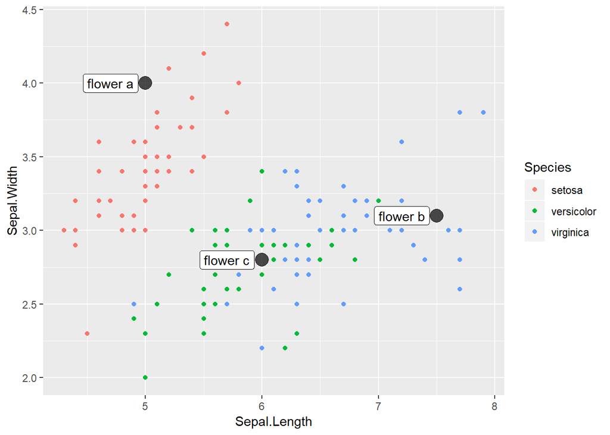

```r
new_observations <- tribble(
  ~Sepal.Length, ~Sepal.Width, ~Species,
  5, 4, "flower a",
  7.5, 3.1, "flower b",
  6, 2.8, "flower c"
)

ggplot(iris,
       aes(x = Sepal.Length, y = Sepal.Width, color = Species)) + geom_point() +
  geom_point(data = new_observations, color = "black", size = 5, alpha = 0.7) +
  geom_label(inherit.aes = FALSE,
             data = new_observations,
             aes(x = Sepal.Length,
                 y = Sepal.Width,
                 label = Species),
             nudge_x=-0.3, show.legend = FALSE)
```

Intuitively we can classify flower a to setosa, flower b to virginica, and flower c is not that “clear cut”. To use KNN, we just need to define the number of neighbors we want the algorithm to use.

The following code shows an example of how to use the KNN algorithm:

```r
# Split iris into train/test randomly
iris_split <- iris %>%
  mutate(is_train = runif(nrow(iris)) <= 0.8)

iris_train <- iris_split %>%
  filter(is_train)

iris_test <- iris_split %>%
  filter(!is_train)

# fit the KNN according to the train set

iris_knn <- class::knn(train = iris_train %>% select(Sepal.Length, Sepal.Width) %>% as.matrix(),
                       test = iris_test %>% select(Sepal.Length, Sepal.Width) %>% as.matrix(),
                       cl = iris_train %>% select(Species) %>% as.matrix(),
                       k = 1)

iris_test %>%
  mutate(knn_class = iris_knn) %>%
  group_by(knn_class, Species) %>%
  tally() %>%
  spread(key = Species, value = n, fill = 0)
```

```
## # A tibble: 3 x 4
## # Groups:   knn_class [3]
##   knn_class  setosa versicolor virginica
##   <fct>       <dbl>      <dbl>     <dbl>
## 1 setosa         11          0         0
## 2 versicolor      0          5         1
## 3 virginica       0          6         8
```

```r
iris_test %>%
  mutate(classification_error = iris_knn != Species) %>%
  group_by(Species) %>%
  summarize(Species_class_error = mean(classification_error))
```

```
## # A tibble: 3 x 2
##   Species    Species_class_error
##   <fct>                    <dbl>
## 1 setosa                   0
## 2 versicolor               0.545
## 3 virginica                0.111
```

### Quiz

The following charts show how KNN looks like for $k\in\{1,2,10\}$.

```r
# generate a full grid:
knn_grid <- expand.grid(Sepal.Length = seq(3, 8, 0.05), Sepal.Width = seq(2, 4.5, 0.05))

# show the result
head(knn_grid)
```

```
##   Sepal.Length Sepal.Width
## 1         3.00           2
## 2         3.05           2
## 3         3.10           2
## 4         3.15           2
## 5         3.20           2
## 6         3.25           2
```

```r
tail(knn_grid)
```

```
##      Sepal.Length Sepal.Width
## 5146         7.75         4.5
## 5147         7.80         4.5
## 5148         7.85         4.5
## 5149         7.90         4.5
## 5150         7.95         4.5
## 5151         8.00         4.5
```

```r
# Run the knn algorithm. Let's use the entire dataset.
# k = 1
iris_knn_1 <- class::knn(train = iris %>% select(Sepal.Length, Sepal.Width) %>% as.matrix(),
                         test = knn_grid,
                         cl = iris %>% select(Species) %>% as.matrix(),
                         k = 1)
# k = 2
iris_knn_2 <- class::knn(train = iris %>% select(Sepal.Length, Sepal.Width) %>% as.matrix(),
                         test = knn_grid,
                         cl = iris %>% select(Species) %>% as.matrix(),
                         k = 2)
# k = 10
iris_knn_10 <- class::knn(train = iris %>% select(Sepal.Length, Sepal.Width) %>% as.matrix(),
                          test = knn_grid,
                          cl = iris %>% select(Species) %>% as.matrix(),
                          k = 10)

# Now, I'm going to plot the resulting grids

knn_for_chart <- knn_grid %>%
  bind_cols(tibble(`1nn` = iris_knn_1, `2nn` = iris_knn_2, `10nn` = iris_knn_10)) %>%
  gather(key = "k", value = "classification", -Sepal.Length, -Sepal.Width) %>%
  mutate(k = as_factor(k, levels = c("1nn", "2nn", "10nn")))

# to show you the data set I'm using to plot this after the gather operation
glimpse(knn_for_chart)
```

```
## Observations: 15,453
## Variables: 4
## $ Sepal.Length   <dbl> 3.00, 3.05, 3.10, 3.15, 3.20, 3.25, 3.30, 3.35,...
## $ Sepal.Width    <dbl> 2, 2, 2, 2, 2, 2, 2, 2, 2, 2, 2, 2, 2, 2, 2, 2,...
## $ k              <fct> 1nn, 1nn, 1nn, 1nn, 1nn, 1nn, 1nn, 1nn, 1nn, 1n...
## $ classification <chr> "setosa", "setosa", "setosa", "setosa", "setosa...
```

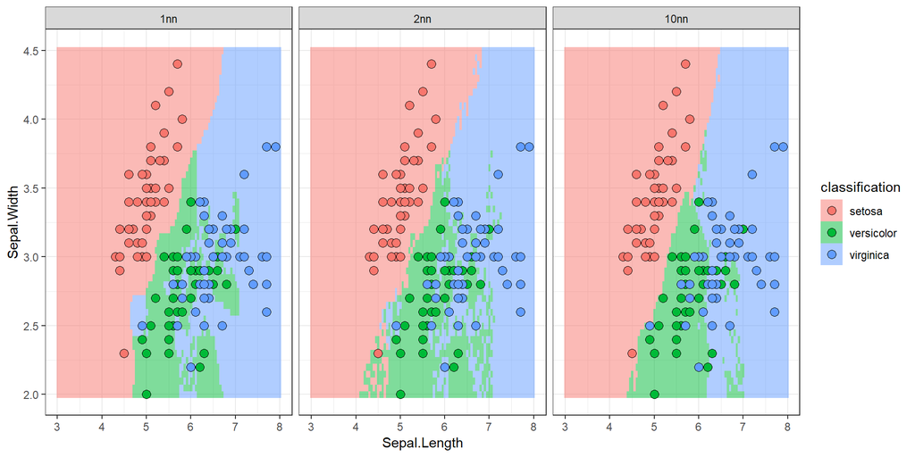

```r
# the ggplot command
ggplot(knn_for_chart, aes(x = Sepal.Length, y = Sepal.Width, fill = classification)) +
  geom_raster(alpha = 0.5) +
  facet_wrap(~ k) +
  geom_point(inherit.aes = F, data = iris, aes(x = Sepal.Length, y = Sepal.Width, fill = Species),
             color = "black", pch = 21, size = 3) +
  theme_bw()
```

## Scaling and centering

One of the tools we sometimes need to employ when using KNN (or other algorithms which are based on distances, such as clustering we previously discussed), is scaling and centering:

- Think about two variables, one in the range of 0-1 and the second in the range of 0-100. The definition of “neighborhood” will be highly influenced by the scale of the second variable.
- Scaling and centering can be used by the `scale` function, just note that it expects a numeric matrix and returns a matrix with attributes. This function works on the distribution (the sd becomes 1 and the mean becomes 0).
- A second option is to build your own scaling function, e.g. min-max. This kind of scaling works on the range of the data.

```r
x_norm <- rnorm(100, 10, 3)
x_scaled <- scale(x_norm)
x_minmax <- (x_norm - min(x_norm))/(max(x_norm)-min(x_norm))

scaling_examples <- tibble(original = x_norm,
       scale_fun = x_scaled,
       scale_minmax = x_minmax) %>%
  gather(type, value)
```

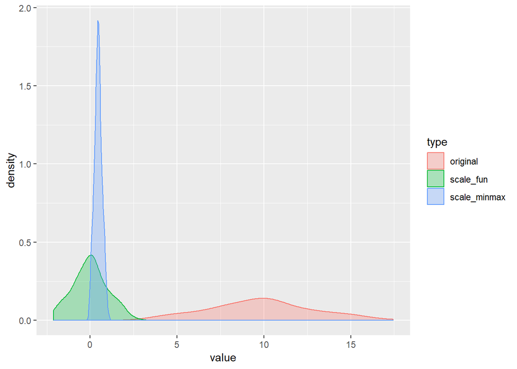

```r
ggplot(scaling_examples, aes(value, color = type, fill = type)) +
  geom_density(alpha = 0.3)
```

### knn exercise

Load the medical appointments file, and split it to two parts randomely (train 80% / test 20%). Use knn to predict no-show (you can use the command from package `FNN` which is faster).

1. What variables do you think you should use?
2. What transformation are you doing on the variables?
3. What is the $k$ you recommend?
4. Compute the type-I (predicted no-show but did show) and type-II errors (predicted show but didn’t show).

```
# load the knn
library(FNN)

# Load the file from the csv
appointments_raw <- read_csv("https://raw.githubusercontent.com/adisarid/Riskified_training/master/datasets/Medical_Appointments_No_Shows_KaggleV2-May-2016.csv")
appointments <- appointments_raw %>%
  mutate(is_train = runif(nrow(appointments_raw)) <= 0.8) %>%
  mutate(schedule_time = lubridate::hour(ScheduledDay)) %>%
  mutate(same_day_appointment = (abs(ScheduledDay - AppointmentDay) <= 24)*1) %>%
  mutate(is_male = (Gender == "M")*1) %>%
  mutate_at(.vars = vars("schedule_time", "Age"), funs((. - min(.))/(max(.)-min(.)))) %>%
  select(XXX)

create_knn_estimation <- function(vars_to_omit = "null", try_k = 1){
  test_res <- knn(train = appointments %>%
                    filter(is_train) %>%
                    select(-XXX, -XXX) %>%
                    as.matrix(),
                  test = appointments %>%
                    filter(!is_train) %>%
                    select(-XXX, -XXX) %>%
                    as.matrix(),
                  cl = appointments %>%
                    filter(is_train) %>%
                    select(`No-show`) %>%
                    as.matrix(),
                  k = XXX)

  # Check for classification errors
  confusion <- tibble(knn_result = as.character(test_res),
                      real_result = appointments$`No-show`[!appointments$is_train]) %>%
    group_by(XXX) %>%
    count(knn_result) %>%
    mutate(prop = XXX) %>%
    select(-n) %>%
    spread(key = knn_result, value = prop)

  return(confusion)

}

confuse1 <- create_knn_estimation()
confuse2 <- create_knn_estimation(try_k = 3)
confuse3 <- create_knn_estimation(try_k = 7)
confuse4 <- create_knn_estimation(try_k = 1, vars_to_omit = "Age")
confuse5 <- create_knn_estimation(try_k = 1, vars_to_omit = c("Age", "same_day_appointment"))
confuse6 <- create_knn_estimation(try_k = 1, vars_to_omit = c("same_day_appointment"))
confuse7 <- create_knn_estimation(try_k = 1, vars_to_omit = c("Age", "is_male"))

confuse1
confuse2
confuse3
confuse4
confuse5
confuse6
confuse7
```

## Some problems with KNN

The computation is inefficient - you need to calculate distance of a new observation from a lot of other points to find its closest neighbors.

Not much statistics can be deduced (e.g. in terms of significance or hypothesis testing).